# Data Science Capstone: Next Word Predictor

14 March, 2022

### Predictive Text

Typing on mobile devices is hard without a full keyboard - now that Blackberry has discontinued support for its devices. To make things easier we’ve built an app that can do this.

Special attention was made to keep the app small and fast while retaining accuracy.

The data used to train the model is a corpus of over four million blog, twitter and news entries. A sample of 250k entries was then cleaned, filtered and separated into 3 data frames:

| Word Format | Minimum Repeated | Observations | Size in bytes |
| --- | --- | --- | --- |
| Single words | 11 | 18.5K | 1.3M |
| 2 word combinations | 6 | 87.6K | 2.8M |
| 3 word combinations | 4 | 98.5K | 3.6M |

### Model Strategy

Three different strategies were attempted:

- Simple next word prediction via n-gram tokenisation - found to be inaccurate doesn’t consider the probability of unseen combinations.
- Markov chain model - great accuracy and speed, however the transition probability matrices created were far too large for use over the internet. More work will be done to remedy this problem
- Katz’s back-off model - fast, accurate and what the model finally used

### Katz’s back-off model

This model considers the probability of a predicted word by combining the probabilities of the word from shorter word combination predictions.

[Here is the Wikipedia entry](https://en.wikipedia.org/wiki/Katz%27s_back-off_model)

A four ngram model was considered, but size and complexity was too burdensome.

### Model performance

A test on the model was made on 10 phrases checking if it could predict the word, where the actual next word was ranked by the model (number 1 is the best possible!), the probability estimated by the model and finally how long this took to process. Here are the results:

| Successful | Test Phrase | Next Word | Predicted Rank | Predicted Probability | Seconds Elapsed |
| --- | --- | --- | --- | --- | --- |
| TRUE | just one shot from | the | 1 | 46.9697% | 0.0522 |
| TRUE | always have to go | to | 1 | 20.2979% | 0.0398 |
| TRUE | rowhouse in riverside three | years | 1 | 3.9757% | 0.0179 |
| TRUE | back and linebacker for | the | 1 | 3.7501% | 0.0170 |
| TRUE | on how i connect | to | 2 | 4.0783% | 0.0175 |
| TRUE | everyone needs to be | getting | 99 | 0.1483% | 0.0449 |
| TRUE | to have a long | attention | 894 | 0.0019% | 0.0406 |
| TRUE | with roasted pumpkin and | plum | 8606 | 0.001% | 0.0189 |
| FALSE | the zionist falseflag scripts | are | NA | NA% | 0.0927 |
| FALSE | other records detail lucrative | nobid | NA | NA% | 0.0040 |

Not bad really, 5 predicted well and the two not predicted are not correctly spealt.

1: Input phrase; 2: Number of predictions shown; 3: Predicted words (bigger is better!)

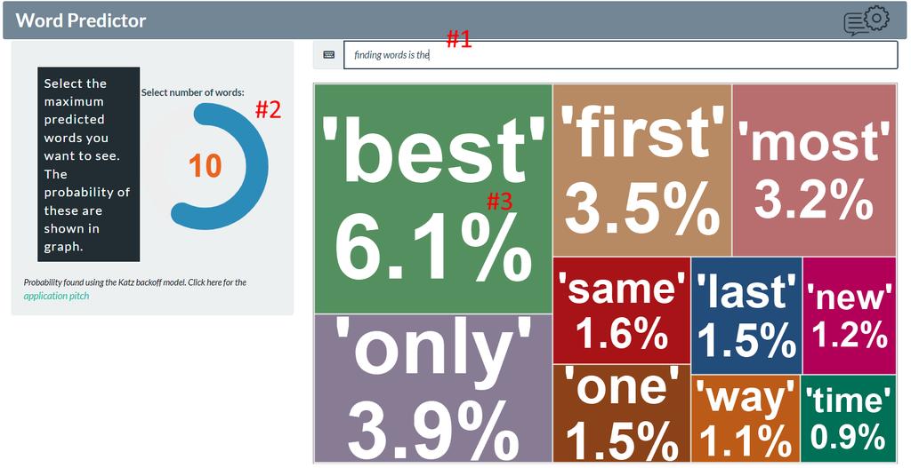

**Thank you for grading my submission!**